# Data Visualization: `ggplot` part 3

## Histograms

Histograms are frequently used by biologists; they show the distribution of continuous variables. As students, you almost certainly have seen histograms of grade distributions. Without getting into the statistics, a histogram `bins` the data and you specify the number of bins that encompass a range of observations. For something like grades, this is easy because the number of bins corresponds to the grades A-F. By default, R uses a formula to calculate the number of bins but some adjustment is often required.

What does the distribution of body mass look like in the `homerange` data?

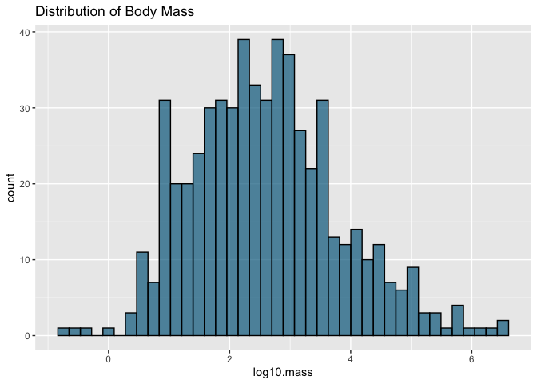

```r
homerange %>%
  ggplot(aes(x = log10.mass)) +
  geom_histogram(alpha = 0.7, color = "black", fill = "deepskyblue4", bins=40)+
  labs(title = "Distribution of Body Mass")
```

```r
#Each bar is a bin and has a black line across it, helps it pop out a bit more
#Color option changes outline. This helps make the bins more clearly
#Fill has a lot of colors for RStudio!
#Alpha refers to transparency. Some transparency lets readers see lines behind plot
```

Let’s play with the colors. This shows all 657 of R’s built-in colors. Notice that `color` and `fill` do different things!

```r
grDevices::colors()
```

```
##   [1] "white"                "aliceblue"            "antiquewhite"
##   [4] "antiquewhite1"        "antiquewhite2"        "antiquewhite3"
##   [7] "antiquewhite4"        "aquamarine"           "aquamarine1"
##  [10] "aquamarine2"          "aquamarine3"          "aquamarine4"
##  [13] "azure"                "azure1"               "azure2"
##  [16] "azure3"               "azure4"               "beige"
##  [19] "bisque"               "bisque1"              "bisque2"
##  [22] "bisque3"              "bisque4"              "black"
##  [25] "blanchedalmond"       "blue"                 "blue1"
##  [28] "blue2"                "blue3"                "blue4"
##  [31] "blueviolet"           "brown"                "brown1"
##  [34] "brown2"               "brown3"               "brown4"
##  [37] "burlywood"            "burlywood1"           "burlywood2"
##  [40] "burlywood3"           "burlywood4"           "cadetblue"
##  [43] "cadetblue1"           "cadetblue2"           "cadetblue3"
```

[output cut: 204 more lines]

## Density plots

Density plots are similar to histograms but they use a smoothing function to make the distribution more even and clean looking. They do not use bins.

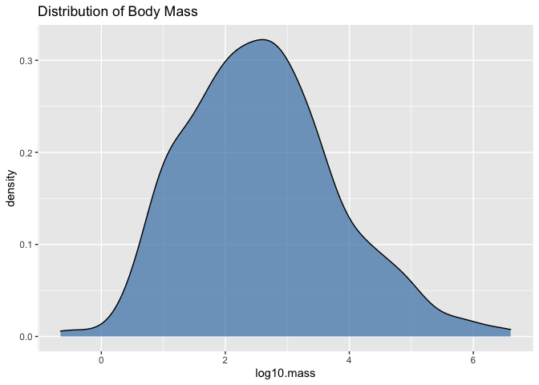

```r
homerange %>%
  ggplot(aes(x = log10.mass)) +
  geom_density(fill="steelblue", alpha  =0.7, color = "black")+
  labs(title = "Distribution of Body Mass")
```

I like to see both the histogram and the density curve so I often plot them together. Note that I assign the density plot a different color.

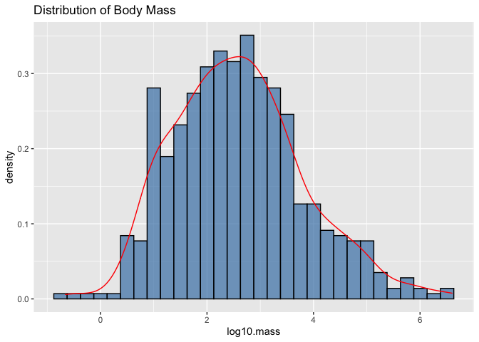

```r
homerange %>%
  ggplot(aes(x=log10.mass)) +
  geom_histogram(aes(y = ..density..), fill = "steelblue", alpha = 0.7, color = "black")+
  geom_density(color = "red")+
  labs(title = "Distribution of Body Mass")
```

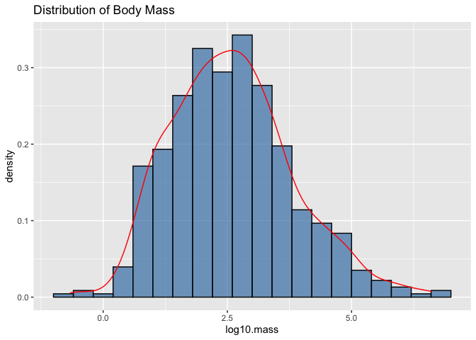

```r
homerange %>%
  ggplot(aes(x=log10.mass)) +
  geom_histogram(aes(y = ..density..), binwidth = .4, fill = "steelblue", alpha = 0.7, color = "black")+
  geom_density(color = "red")+
  labs(title = "Distribution of Body Mass")
```

## Practice

1. Make a histogram of `log10.hra`. Make sure to add a title.

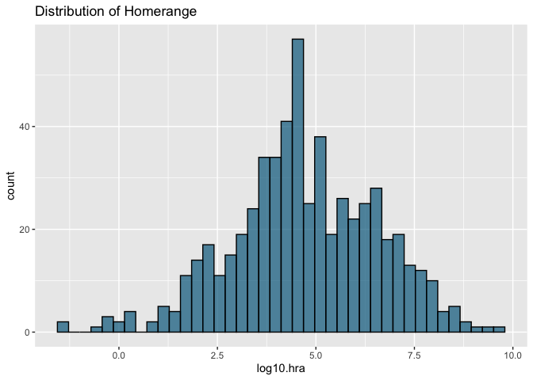

```r
homerange %>%
  ggplot(aes(x=log10.hra))+
  geom_histogram(fill="deepskyblue4", alpha=0.7, color="black", bins=40)+
  labs(title="Distribution of Homerange")
```

2. Now plot the same variable using `geom_density()`.

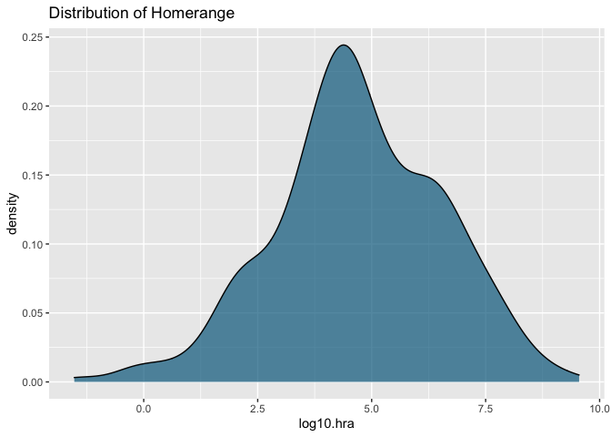

```r
homerange %>%
  ggplot(aes(x=log10.hra))+
  geom_density(fill="deepskyblue4", alpha=0.7, color="black", bins=40)+
  labs(title="Distribution of Homerange")
```

3. Combine them both!

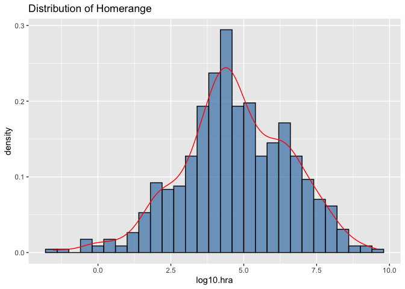

```r
homerange %>%
  ggplot(aes(x=log10.hra)) +
  geom_histogram(aes(y = ..density..), binwidth = .4, fill = "steelblue", alpha = 0.7, color = "black")+
  geom_density(color = "red")+
  labs(title = "Distribution of Homerange")
```

## Create Categories with mutate and case_when()

`case_when()` is a very handy function from `dplyr` which allows us to calculate a new variable from other variables. We use `case_when()` within `mutate()` to do this.`case_when()` allows us to specify multiple conditions. Let’s reclassify the body mass variable into a new factor variable with small, medium, and large animals.

```r
glimpse(homerange)
```

```
## Rows: 569
## Columns: 24
## $ taxon                      <chr> "lake fishes", "river fishes", "river fish…
## $ common.name                <chr> "american eel", "blacktail redhorse", "cen…
## $ class                      <chr> "actinopterygii", "actinopterygii", "actin…
## $ order                      <chr> "anguilliformes", "cypriniformes", "cyprin…
## $ family                     <chr> "anguillidae", "catostomidae", "cyprinidae…
## $ genus                      <chr> "anguilla", "moxostoma", "campostoma", "cl…
## $ species                    <chr> "rostrata", "poecilura", "anomalum", "fund…
## $ primarymethod              <chr> "telemetry", "mark-recapture", "mark-recap…
## $ N                          <chr> "16", NA, "20", "26", "17", "5", "2", "2",…
## $ mean.mass.g                <dbl> 887.00, 562.00, 34.00, 4.00, 4.00, 3525.00…
## $ log10.mass                 <dbl> 2.9479236, 2.7497363, 1.5314789, 0.6020600…
## $ alternative.mass.reference <chr> NA, NA, NA, NA, NA, NA, NA, NA, NA, NA, NA…
## $ mean.hra.m2                <dbl> 282750.00, 282.10, 116.11, 125.50, 87.10, …
## $ log10.hra                  <dbl> 5.4514026, 2.4504031, 2.0648696, 2.0986437…
## $ hra.reference              <chr> "Minns, C. K. 1995. Allometry of home rang…
## $ realm                      <chr> "aquatic", "aquatic", "aquatic", "aquatic"…
## $ thermoregulation           <chr> "ectotherm", "ectotherm", "ectotherm", "ec…
## $ locomotion                 <chr> "swimming", "swimming", "swimming", "swimm…
## $ trophic.guild              <chr> "carnivore", "carnivore", "carnivore", "ca…
## $ dimension                  <chr> "3D", "2D", "2D", "2D", "2D", "2D", "2D", …
## $ preymass                   <dbl> NA, NA, NA, NA, NA, NA, 1.39, NA, NA, NA, …
## $ log10.preymass             <dbl> NA, NA, NA, NA, NA, NA, 0.1430148, NA, NA,…
## $ PPMR                       <dbl> NA, NA, NA, NA, NA, NA, 530, NA, NA, NA, N…
## $ prey.size.reference        <chr> NA, NA, NA, NA, NA, NA, "Brose U, et al. 2…
```

```r
#A lot of variables continuous. What if we want to make some categorical?
```

```r
homerange %>%
  select(log10.mass) %>%
  summarise(min=min(log10.mass),
            max=max(log10.mass))
```

```
## # A tibble: 1 x 2
##      min   max
##    <dbl> <dbl>
## 1 -0.658  6.60
```

```r
#Breaking up data with continuous variables
#Negative min value is due to log value
#How to break these up?
```

```r
summary(homerange$log10.mass)
```

```
##    Min. 1st Qu.  Median    Mean 3rd Qu.    Max.
## -0.6576  1.6990  2.5185  2.5947  3.3324  6.6021
```

```r
#Using quartiles to help make distribution
```

```r
homerange <- homerange %>%
             mutate(mass_category = case_when(log10.mass <= 1.75 ~ "small",
                                              log10.mass > 1.75 & log10.mass <= 2.75 ~ "medium",
                                              log10.mass > 2.75 ~ "large"))
#Mutating to add a new column, and making mass categories
#Case_when categorized variables
glimpse(homerange)
```

```
## Rows: 569
## Columns: 25
## $ taxon                      <chr> "lake fishes", "river fishes", "river fish…
## $ common.name                <chr> "american eel", "blacktail redhorse", "cen…
## $ class                      <chr> "actinopterygii", "actinopterygii", "actin…
## $ order                      <chr> "anguilliformes", "cypriniformes", "cyprin…
## $ family                     <chr> "anguillidae", "catostomidae", "cyprinidae…
## $ genus                      <chr> "anguilla", "moxostoma", "campostoma", "cl…
## $ species                    <chr> "rostrata", "poecilura", "anomalum", "fund…
## $ primarymethod              <chr> "telemetry", "mark-recapture", "mark-recap…
## $ N                          <chr> "16", NA, "20", "26", "17", "5", "2", "2",…
## $ mean.mass.g                <dbl> 887.00, 562.00, 34.00, 4.00, 4.00, 3525.00…
## $ log10.mass                 <dbl> 2.9479236, 2.7497363, 1.5314789, 0.6020600…
## $ alternative.mass.reference <chr> NA, NA, NA, NA, NA, NA, NA, NA, NA, NA, NA…
## $ mean.hra.m2                <dbl> 282750.00, 282.10, 116.11, 125.50, 87.10, …
## $ log10.hra                  <dbl> 5.4514026, 2.4504031, 2.0648696, 2.0986437…
## $ hra.reference              <chr> "Minns, C. K. 1995. Allometry of home rang…
## $ realm                      <chr> "aquatic", "aquatic", "aquatic", "aquatic"…
## $ thermoregulation           <chr> "ectotherm", "ectotherm", "ectotherm", "ec…
## $ locomotion                 <chr> "swimming", "swimming", "swimming", "swimm…
## $ trophic.guild              <chr> "carnivore", "carnivore", "carnivore", "ca…
## $ dimension                  <chr> "3D", "2D", "2D", "2D", "2D", "2D", "2D", …
## $ preymass                   <dbl> NA, NA, NA, NA, NA, NA, 1.39, NA, NA, NA, …
## $ log10.preymass             <dbl> NA, NA, NA, NA, NA, NA, 0.1430148, NA, NA,…
## $ PPMR                       <dbl> NA, NA, NA, NA, NA, NA, 530, NA, NA, NA, N…
## $ prey.size.reference        <chr> NA, NA, NA, NA, NA, NA, "Brose U, et al. 2…
## $ mass_category              <chr> "large", "medium", "small", "small", "smal…
```

Here we check how the newly created body mass categories compare across `trophic.guild`.

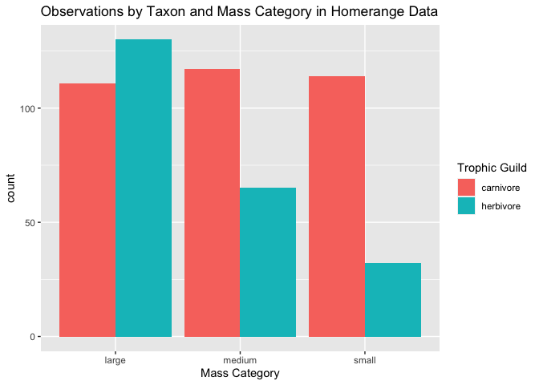

```r
homerange %>%
  ggplot(aes(x = mass_category, fill = trophic.guild)) +
  geom_bar(position="dodge") +
  labs(title = "Observations by Taxon and Mass Category in Homerange Data",
       x = "Mass Category",
       fill = "Trophic Guild")
```

```r
#Made mass category into a categorical variable
```

So basically keep the case_when() function in mind for future projects!

## Practice

1. Use case_when() to make a new column `range_category` that breaks down `log10.hra` into very small, small, medium, and large classes based on quartile.

```r
summary(homerange$log10.hra)
```

```
##    Min. 1st Qu.  Median    Mean 3rd Qu.    Max.
##  -1.523   3.653   4.595   4.709   6.016   9.550
```

```r
library(gtools)
quartiles<-quantcut(homerange$log10.hra)
table(quartiles)
```

```
## quartiles
## [-1.52,3.65]  (3.65,4.59]  (4.59,6.02]  (6.02,9.55]
##          143          142          142          142
```

```r
homerange <- homerange %>%
  mutate(range_category= case_when(log10.hra<3.65 ~ "very small",
                                   log10.hra>=3.65 & log10.hra<4.49 ~ "small",#next quartile
                                   log10.hra>=4.49 & log10.hra<6.02 ~ "medium",
                                   log10.hra>=6.02 ~ "large"))
#3.65 is the quartile value in the first column/row, "y" value
```

```r
glimpse(homerange)
```

```
## Rows: 569
## Columns: 26
## $ taxon                      <chr> "lake fishes", "river fishes", "river fish…
## $ common.name                <chr> "american eel", "blacktail redhorse", "cen…
## $ class                      <chr> "actinopterygii", "actinopterygii", "actin…
## $ order                      <chr> "anguilliformes", "cypriniformes", "cyprin…
## $ family                     <chr> "anguillidae", "catostomidae", "cyprinidae…
## $ genus                      <chr> "anguilla", "moxostoma", "campostoma", "cl…
## $ species                    <chr> "rostrata", "poecilura", "anomalum", "fund…
## $ primarymethod              <chr> "telemetry", "mark-recapture", "mark-recap…
## $ N                          <chr> "16", NA, "20", "26", "17", "5", "2", "2",…
## $ mean.mass.g                <dbl> 887.00, 562.00, 34.00, 4.00, 4.00, 3525.00…
## $ log10.mass                 <dbl> 2.9479236, 2.7497363, 1.5314789, 0.6020600…
## $ alternative.mass.reference <chr> NA, NA, NA, NA, NA, NA, NA, NA, NA, NA, NA…
## $ mean.hra.m2                <dbl> 282750.00, 282.10, 116.11, 125.50, 87.10, …
## $ log10.hra                  <dbl> 5.4514026, 2.4504031, 2.0648696, 2.0986437…
## $ hra.reference              <chr> "Minns, C. K. 1995. Allometry of home rang…
## $ realm                      <chr> "aquatic", "aquatic", "aquatic", "aquatic"…
## $ thermoregulation           <chr> "ectotherm", "ectotherm", "ectotherm", "ec…
## $ locomotion                 <chr> "swimming", "swimming", "swimming", "swimm…
## $ trophic.guild              <chr> "carnivore", "carnivore", "carnivore", "ca…
## $ dimension                  <chr> "3D", "2D", "2D", "2D", "2D", "2D", "2D", …
## $ preymass                   <dbl> NA, NA, NA, NA, NA, NA, 1.39, NA, NA, NA, …
## $ log10.preymass             <dbl> NA, NA, NA, NA, NA, NA, 0.1430148, NA, NA,…
## $ PPMR                       <dbl> NA, NA, NA, NA, NA, NA, 530, NA, NA, NA, N…
## $ prey.size.reference        <chr> NA, NA, NA, NA, NA, NA, "Brose U, et al. 2…
## $ mass_category              <chr> "large", "medium", "small", "small", "smal…
## $ range_category             <chr> "medium", "very small", "very small", "ver…
```

```r
#Worked, shows it did in the very bottom row
```

2. How many and which taxonomic classes are represented in each of the `range_category` classes?

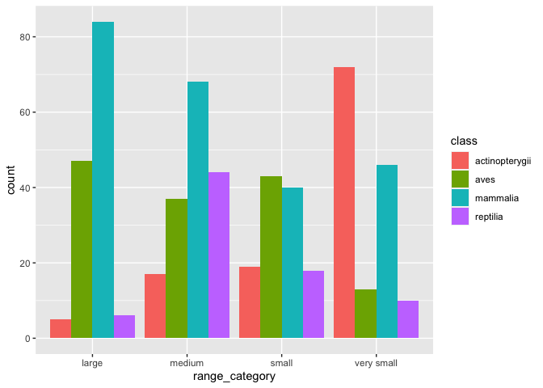

```r
homerange %>%
  ggplot(aes(x = range_category, fill = class))+
  geom_bar(position="dodge")
```

```r
#Range category broken up into large, medium, small, very small
```

3. Isolate the small `range_category` and plot the range of `log10.mass` by taxonomic class.

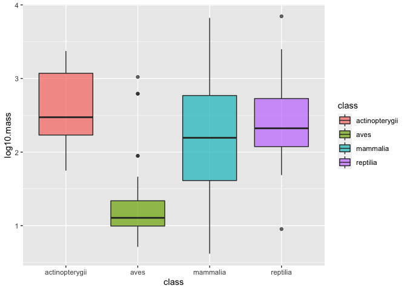

```r
homerange %>%
  filter(range_category=="small") %>%
  ggplot(aes(x = class, y = log10.mass, fill = class))+
  geom_boxplot(alpha = 0.7)
```

## That’s it! Take a break and I will see you on Zoom!

–>[Home](https://jmledford3115.github.io/datascibiol/)